# FlightOps Insight - Statistical Analysis

OTP hypothesis tests and C-MAPSS time-to-critical survival analysis

FlightOps Insight prototype

04 November 2026

# 1 Purpose and scope

This notebook tests whether the descriptive patterns used in the Streamlit app are statistically distinguishable from noise, and it models the time until an engine enters the 20-cycle critical zone in NASA C-MAPSS FD001.

All inputs are public data or deterministic extracts from this repository. The tests are associational. They do not identify causal effects, and the C-MAPSS data are simulated degradation trajectories rather than a fleet feed.

# 2 OTP hypothesis tests

## 2.1 Peak versus off-peak delay risk

The app claims that delay risk rises through the operating day. We compare the 15:00-20:00 block with the 06:00-09:00 block using a one-sided two-proportion test.

```r
hourly <- read.csv(file.path(metrics_dir, "r_otp_hourly.csv"))
peak <- subset(hourly, dep_hour >= 15 & dep_hour <= 20)
off <- subset(hourly, dep_hour >= 6 & dep_hour <= 9)

peak_n <- sum(peak$flights)
off_n <- sum(off$flights)
peak_x <- round(sum(peak$flights * peak$delay_rate))
off_x <- round(sum(off$flights * off$delay_rate))

c(peak_flights = peak_n, peak_delayed = peak_x, peak_rate = peak_x / peak_n,
  off_flights = off_n, off_delayed = off_x, off_rate = off_x / off_n)
```

```
## peak_flights peak_delayed    peak_rate  off_flights  off_delayed     off_rate
##    2.401e+06    6.864e+05    2.858e-01    1.867e+06    2.004e+05    1.073e-01
```

```r
prop.test(c(peak_x, off_x), c(peak_n, off_n), alternative = "greater")
```

```
##
##  2-sample test for equality of proportions with continuity correction
##
## data:  c(peak_x, off_x) out of c(peak_n, off_n)
## X-squared = 2e+05, df = 1, p-value <2e-16
## alternative hypothesis: greater
## 95 percent confidence interval:
##  0.1779 1.0000
## sample estimates:
## prop 1 prop 2
## 0.2858 0.1073
```

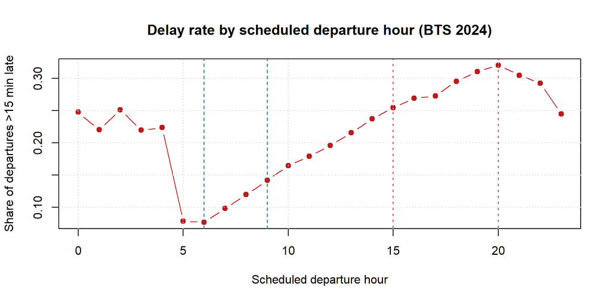

```r
plot(hourly$dep_hour, hourly$delay_rate, type = "b", pch = 19, col = "#b91c1c",
     xlab = "Scheduled departure hour", ylab = "Share of departures >15 min late",
     main = "Delay rate by scheduled departure hour (BTS 2024)")
abline(v = c(6, 9), col = "#0f766e", lty = 2)
abline(v = c(15, 20), col = "#b91c1c", lty = 2)
grid(col = "grey85")
```

**Reading.** The afternoon rate is 28.6% versus 10.7% in the morning block (a difference of about 17.8 percentage points, roughly 2.7x). The one-sided test rejects equality with p < 2.2e-16. With millions of flights the p-value is not the interesting part; the effect size and its stability across months are.

## 2.2 Turnaround bucket and departure delay

Short scheduled turnarounds are associated with higher delay rates. We test independence of delay status and turnaround bucket with a chi-square test on the aggregated 2 x k table.

```r
turn <- read.csv(file.path(metrics_dir, "r_otp_turnaround.csv"))
turn$turn_bucket <- factor(turn$turn_bucket,
  levels = c("< 40 min", "40-59 min", "60-89 min", "90-149 min", "150+ min", "No inbound link"))
turn <- turn[order(turn$turn_bucket), ]
turn$delay_rate <- turn$delayed / turn$flights
turn
```

|  | turn_bucket | flights | delayed | on_time | delay_rate |
| --- | --- | --- | --- | --- | --- |
| 5 | < 40 min | 512716 | 142666 | 370050 | 0.2783 |
| 2 | 40-59 min | 2282903 | 528116 | 1754787 | 0.2313 |
| 3 | 60-89 min | 1662052 | 316812 | 1345240 | 0.1906 |
| 4 | 90-149 min | 450726 | 69917 | 380809 | 0.1551 |
| 1 | 150+ min | 1432122 | 159462 | 1272660 | 0.1113 |
| 6 | No inbound link | 645571 | 226168 | 419403 | 0.3503 |

```r
table_2k <- as.matrix(turn[, c("delayed", "on_time")])
rownames(table_2k) <- turn$turn_bucket
chisq.test(table_2k)
```

```
##
##  Pearson's Chi-squared test
##
## data:  table_2k
## X-squared = 2e+05, df = 5, p-value <2e-16
```

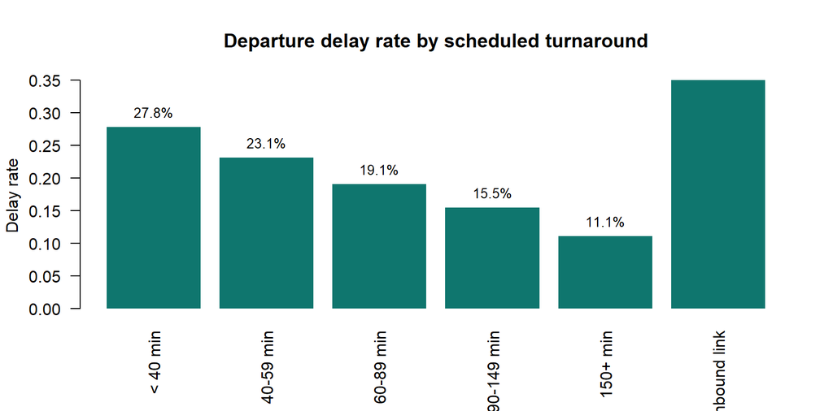

```r
bp <- barplot(turn$delay_rate, names.arg = turn$turn_bucket, las = 2,
              col = "#0f766e", border = NA,
              ylab = "Delay rate", main = "Departure delay rate by scheduled turnaround")
text(bp, turn$delay_rate, labels = sprintf("%.1f%%", 100 * turn$delay_rate),
     pos = 3, cex = 0.85)
```

## 2.3 Seasonality: daily delay rate by month

We use daily network delay rates and a Kruskal-Wallis test because daily rates are not plausibly normal and the month groups differ in size.

```r
daily <- read.csv(file.path(metrics_dir, "r_otp_daily.csv"))
daily$month <- factor(daily$month)
kruskal.test(delay_rate ~ month, data = daily)
```

```
##
##  Kruskal-Wallis rank sum test
##
## data:  delay_rate by month
## Kruskal-Wallis chi-squared = 163, df = 11, p-value <2e-16
```

```r
aggregate(delay_rate ~ month, data = daily, FUN = function(x) c(mean = mean(x), median = median(x), n = length(x)))
```

[output not shown]

[output cut: 2 more lines]

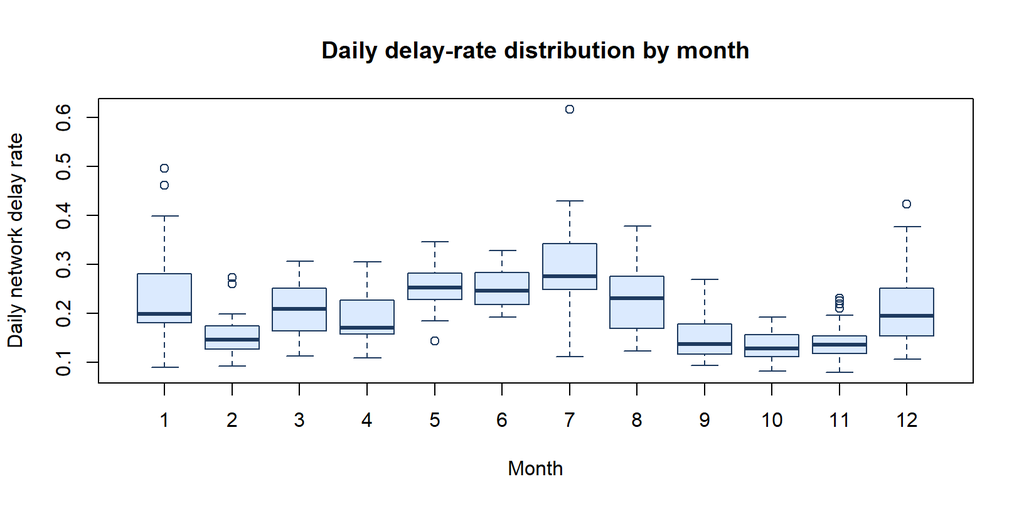

```r
boxplot(delay_rate ~ month, data = daily, col = "#dbeafe", border = "#1e3a5f",
        xlab = "Month", ylab = "Daily network delay rate",
        main = "Daily delay-rate distribution by month")
```

**Reading.** Seasonality is material: July is the worst month and October the best in 2024. The Kruskal-Wallis statistic is 162.6 on 11 degrees of freedom (p < 2.2e-16), so at least one month differs. The box plot shows the practical spread and the winter/summer tails.

## 2.4 Late inbound aircraft

The app describes late inbound aircraft as a leading indicator. We compare “inbound 60+ minutes late” with “inbound early” using a one-sided proportion test.

```r
inbound <- read.csv(file.path(metrics_dir, "r_otp_inbound.csv"))
late <- subset(inbound, segment == "Inbound 60+ min late")
early <- subset(inbound, segment == "Inbound early")
c(late_rate = late$delayed / late$flights, early_rate = early$delayed / early$flights)
```

```
##  late_rate early_rate
##    0.16586    0.09351
```

```r
prop.test(c(late$delayed, early$delayed), c(late$flights, early$flights), alternative = "greater")
```

```
##
##  2-sample test for equality of proportions with continuity correction
##
## data:  c(late$delayed, early$delayed) out of c(late$flights, early$flights)
## X-squared = 9760, df = 1, p-value <2e-16
## alternative hypothesis: greater
## 95 percent confidence interval:
##  0.07088 1.00000
## sample estimates:
##  prop 1  prop 2
## 0.16586 0.09351
```

**Reading.** Flights whose inbound aircraft was already 60+ minutes late depart late 16.6% of the time versus 9.4% when the inbound was early (one-sided p < 2.2e-16). The direction is consistent with a late-aircraft propagation mechanism, but the comparison is confounded by scheduled turnaround buffer, route mix and carrier operating practices. The app therefore calls this an association, not a causal effect.

# 3 C-MAPSS survival analysis

## 3.1 Event definition and censoring

The event is **entry into the 20-cycle critical zone**, not physical failure. This matches the alert threshold used by the RUL model.

- Training units run to failure, so the event is observed for all 100 units.
- Test units are truncated by NASA. If the reported true RUL is above 20, the unit is censored at its last observed cycle. If the true RUL is at or below 20, the crossing time is reconstructed from the reported RUL.

```r
surv <- read.csv(file.path(metrics_dir, "r_rul_survival.csv"))
surv$split <- factor(surv$split, levels = c("train", "test"))
table(surv$split, surv$event)
```

```
##
##           0   1
##   train   0 100
##   test   84  16
```

```r
summary(surv$duration)
```

```
##    Min. 1st Qu.  Median    Mean 3rd Qu.    Max.
##      31     130     160     159     189     343
```

## 3.2 Kaplan-Meier estimate

```r
km <- survfit(Surv(duration, event) ~ 1, data = surv)
km
```

```
## Call: survfit(formula = Surv(duration, event) ~ 1, data = surv)
##
##        n events median 0.95LCL 0.95UCL
## [1,] 200    116    183     180     194
```

```r
summary(km, times = c(50, 100, 150, 200, 250))
```

```
## Call: survfit(formula = Surv(duration, event) ~ 1, data = surv)
##
##  time n.risk n.event survival std.err lower 95% CI upper 95% CI
##    50    193       0    1.000  0.0000       1.0000        1.000
##   100    170       0    1.000  0.0000       1.0000        1.000
##   150    115      27    0.822  0.0313       0.7625        0.885
##   200     33      61    0.306  0.0426       0.2332        0.402
##   250     13      17    0.138  0.0339       0.0849        0.223
```

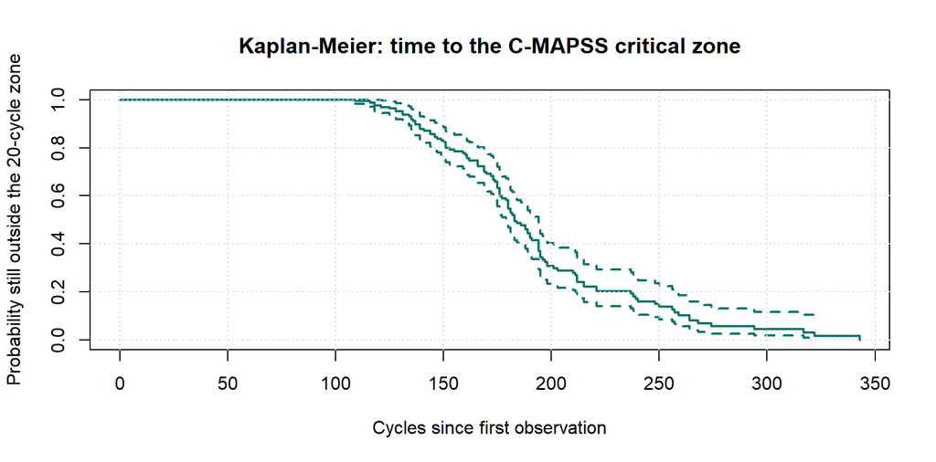

```r
plot(km, conf.int = TRUE, col = "#0f766e", lwd = 2,
     xlab = "Cycles since first observation", ylab = "Probability still outside the 20-cycle zone",
     main = "Kaplan-Meier: time to the C-MAPSS critical zone")
grid(col = "grey85")
```

## 3.3 Kaplan-Meier by early-life degradation slope

We split units at the median early-life slope of sensor 4 (fan inlet temperature proxy in this dataset) and compare curves with a log-rank test.

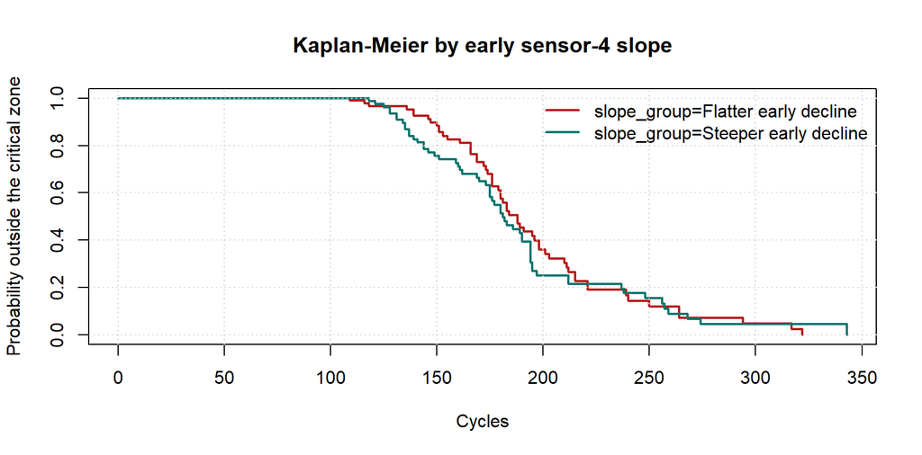

```r
surv$slope_group <- ifelse(surv$slope_sensor_4 <= median(surv$slope_sensor_4),
                           "Steeper early decline", "Flatter early decline")
km_group <- survfit(Surv(duration, event) ~ slope_group, data = surv)
plot(km_group, col = c("#b91c1c", "#0f766e"), lwd = 2, lty = 1,
     xlab = "Cycles", ylab = "Probability outside the critical zone",
     main = "Kaplan-Meier by early sensor-4 slope")
legend("topright", legend = names(km_group$strata), col = c("#b91c1c", "#0f766e"), lwd = 2, bty = "n")
grid(col = "grey85")
```

```r
survdiff(Surv(duration, event) ~ slope_group, data = surv)
```

```
## Call:
## survdiff(formula = Surv(duration, event) ~ slope_group, data = surv)
##
##                                     N Observed Expected (O-E)^2/E (O-E)^2/V
## slope_group=Flatter early decline 100       57     60.6     0.219     0.475
## slope_group=Steeper early decline 100       59     55.4     0.240     0.475
##
##  Chisq= 0.5  on 1 degrees of freedom, p= 0.5
```

**Reading.** The log-rank test is not significant (chi-square 0.5 on 1 degree of freedom, p = 0.50). In this dataset, the early-life sensor-4 slope does **not** separate time-to-critical. That is a useful negative result: a single early-life snapshot is not a substitute for the recent-window trajectory features used by the XGBoost and LSTM models.

## 3.4 Cox proportional hazards model

The Cox model estimates the association between early-life covariates and the hazard of entering the critical zone. Covariates are standardised so hazard ratios are per one standard deviation.

```r
cox <- coxph(Surv(duration, event) ~ scale(init_sensor_11) + scale(init_sensor_4) +
               scale(slope_sensor_4) + scale(slope_sensor_11),
             data = surv)
summary(cox)
```

```
## Call:
## coxph(formula = Surv(duration, event) ~ scale(init_sensor_11) +
##     scale(init_sensor_4) + scale(slope_sensor_4) + scale(slope_sensor_11),
##     data = surv)
##
##   n= 200, number of events= 116
##
##                           coef exp(coef) se(coef)     z Pr(>|z|)
## scale(init_sensor_11)   0.0425    1.0434   0.1472  0.29     0.77
## scale(init_sensor_4)    0.1945    1.2146   0.1397  1.39     0.16
## scale(slope_sensor_4)  -0.0305    0.9699   0.0966 -0.32     0.75
## scale(slope_sensor_11)  0.0410    1.0419   0.0956  0.43     0.67
##
##                        exp(coef) exp(-coef) lower .95 upper .95
## scale(init_sensor_11)       1.04      0.958     0.782      1.39
## scale(init_sensor_4)        1.21      0.823     0.924      1.60
## scale(slope_sensor_4)       0.97      1.031     0.803      1.17
## scale(slope_sensor_11)      1.04      0.960     0.864      1.26
##
## Concordance= 0.591  (se = 0.03 )
## Likelihood ratio test= 5.82  on 4 df,   p=0.2
## Wald test            = 5.74  on 4 df,   p=0.2
## Score (logrank) test = 5.78  on 4 df,   p=0.2
```

```r
cox.zph(cox)
```

```
##                          chisq df     p
## scale(init_sensor_11)  5.25337  1 0.022
## scale(init_sensor_4)   2.92987  1 0.087
## scale(slope_sensor_4)  0.91700  1 0.338
## scale(slope_sensor_11) 0.00114  1 0.973
## GLOBAL                 6.96221  4 0.138
```

**Reading.** No covariate is individually significant at the 5% level. The largest point estimate is initial sensor 4 (HR 1.21 per SD, 95% CI 0.92-1.60), but the interval includes 1. The global proportional-hazards test is not significant (p = 0.14), though the initial sensor-11 term shows a local departure (p = 0.022). The model is illustrative and is not used by the production RUL scorer.

# 4 Conclusions

- Afternoon departures carry a materially higher delay rate than morning departures; the proportion test quantifies the difference and its uncertainty.
- Delay status is not independent of scheduled turnaround length. Short turns are a practical intervention point, but the data are observational.
- Seasonality is statistically and operationally material.
- Late inbound aircraft are associated with higher departure-delay risk, with confounding from turnaround buffer and network mix.
- In C-MAPSS, the median time to the 20-cycle zone is about 183 cycles. Early-life sensor slopes did **not** separate time-to-critical (log-rank p = 0.50), and the Cox covariates were not individually significant. This negative result argues against using a single early-life snapshot; the production RUL models use recent trajectories and achieve much lower error.
- The survival event is a maintenance threshold, not a physical failure, and the dataset is simulated. These results cannot be transferred to a fleet without validation on real run-to-failure and censored service data.